# Project 2 Draft - Felix

Felix Pham

8/11/2019

#### Figure 3:

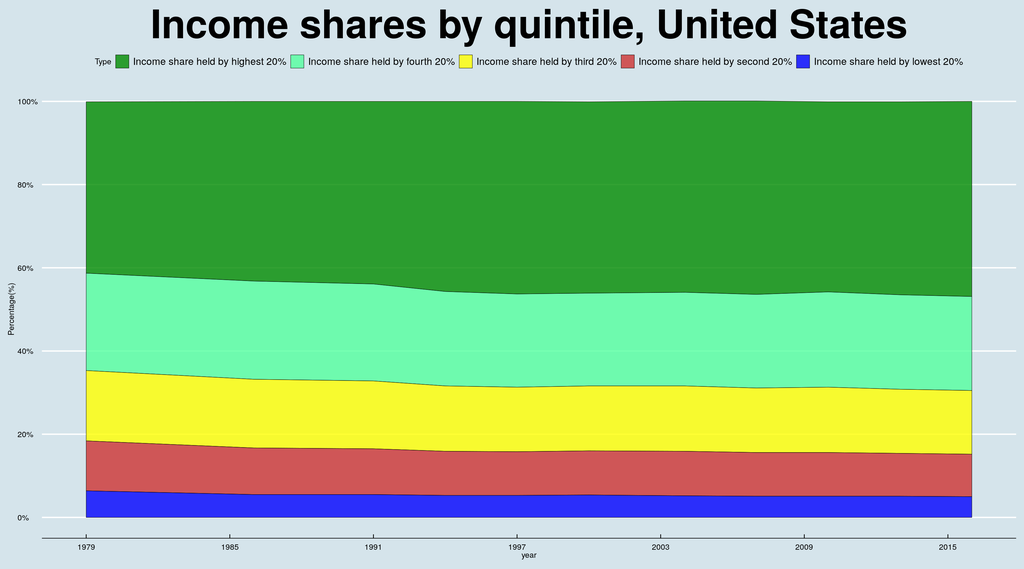

This chart shows, in the U.S, the evolution of shares of total income going to the richest 20% (and subsequent quintiles).

## Methodology

Global inequality of opportunity Living conditions are vastly unequal between different places in our world today. And they have also changed over time: in some places living conditions changed dramatically, in others more slowly.

Today’s global inequality is the consequence of two centuries of unequal progress. Some places have seen dramatic improvements, while others have not. It is on us today to even the odds and give everyone – no matter where they are born – the chance of a good life. This is not only right, but, as we will see below, is also realistic. Our hope for giving the next generations the chance to live a good life lies in broad development that makes possible for everyone what is only attainable for few today.

It strikes many people as inherently unfair that some people are able to enjoy healthy, wealthy, happy lives whilst others continue to live in ill-health, poverty and sorrow. For them it is the inequality in the outcomes of people’s lives that matters. For others it is the inequality in opportunity – the opportunity to achieve good outcomes – that is unfair. But the point of this text is to say that these two aspects of inequality are not separable. Tony Atkinson said it very clearly: “Inequality of outcome among today’s generation is the source of the unfair advantage received by the next generation. If we are concerned about equality of opportunity tomorrow, we need to be concerned about inequality of outcome today.”2

The extent of global inequality – it is not who you are, but where you are Today’s global inequality of opportunity means that what matters most for your living conditions is the good or bad luck of your place of birth.

The inequality between countries that I am focusing on in this text is not the only aspect that needs to be considered. Inequalities within countries and societies – regional differences, racial differences, gender differences, and inequalities across other dimensions – can also be large, and are all beyond any individual’s own control and unfair in the same way.

The inequality between different places in the world is much larger than the difference you can make on your own.

When you are born in a poor place where every tenth child dies you will not be able to get the odds of your baby dying down to the average level of countries with the best child health.

In a place where the average child can only expect 5 years of education it will be immensely harder for a child to obtain the level of education even the average child gets in the best-off places.

The difference is even starker for incomes. In a place where GDP per capita is less than $1,000 and the majority lives in extreme poverty, the average incomes in a rich country are unattainable. In a text I am publishing soon I will be looking at the research that studies how much the place of birth matters for people’s material prosperity: The short answer is that where you live isn’t just more important than all your other characteristics, it’s more important than everything else put together.

You cannot get healthy and wealthy on your own – Societies make progress, not individuals What is true for inequality across countries around the world today, is also true for change over time. What gives people the chance for a good life is when the entire society and economy around them changes for the better. This is what development and economic growth are about: transforming a place so that what was previously only attainable for the luckiest few comes into reach for most.